# MP2: FEC Data

Abby Doctor, Sarah Elghazoly

## Introduction

In this project, we analyzed data collected by the Federal Election Commission, a government regulatory organization overseeing campaign finance information.

The FEC datasets available for our investigation included `house_elections`, `candidates`, `contributions`, `committees`.

In the course of our project, we chose to analyze three of these datasets, for which we have included a short description of each.

### The Data:

- `house_elections`: This dataset features voter-turnout information (`primary_votes`, `general_votes`, `ge_winner`) as well as candidate- and district-specific voter details for each house of representative candidates in the 2012 election cycle.
- `candidates` : This dataset includes basic candidate information (`cand_name`, `cand_party_affiliation`, `cand_election_yr`, `cand_office_state`, etc.) for each candidate who has registered with the FEC or appears on a ballot list prepared by a state elections office.
- `contributions` : This dataset includes contribution information for each contribution or independent expenditure made by a political action committee (PAC), party committee, candidate committee, or other federal committee to a candidate during the two-year election cycle.
- `committees` : This dataset contains one record for each committee registerd with the FEC. It features basic committee information.

## Incumbents in House

This graphic shows the effects of incumbency on the election chances by breaking the house_elections data set to its winners, and by state showing how many election winners were incumbents.

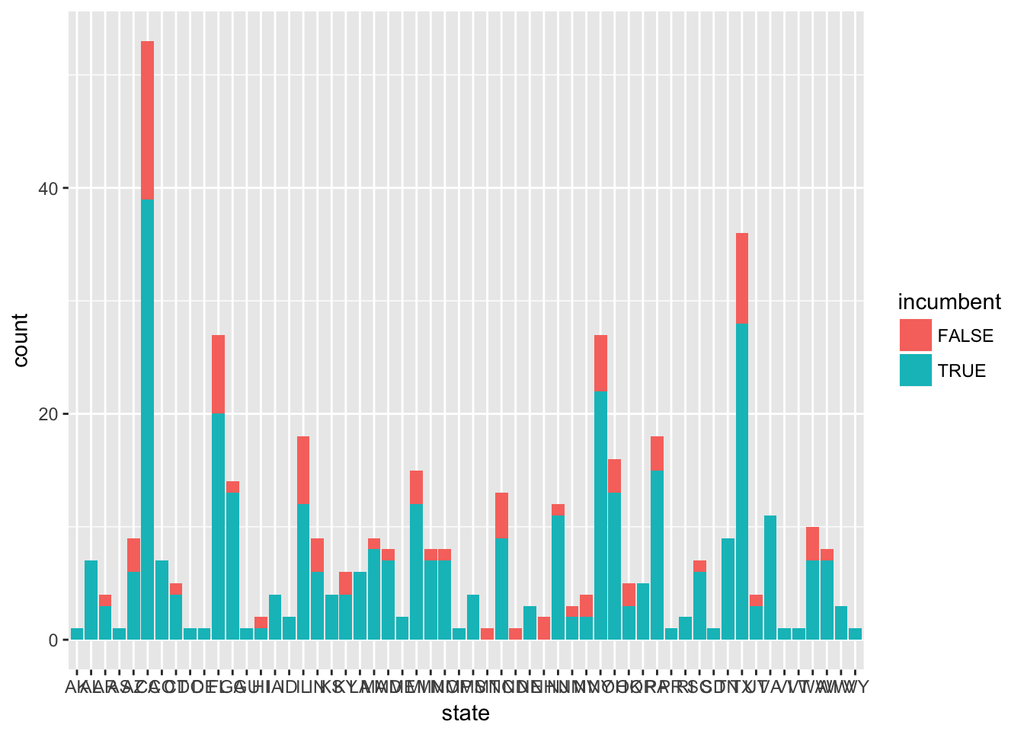

## Contributions per Party

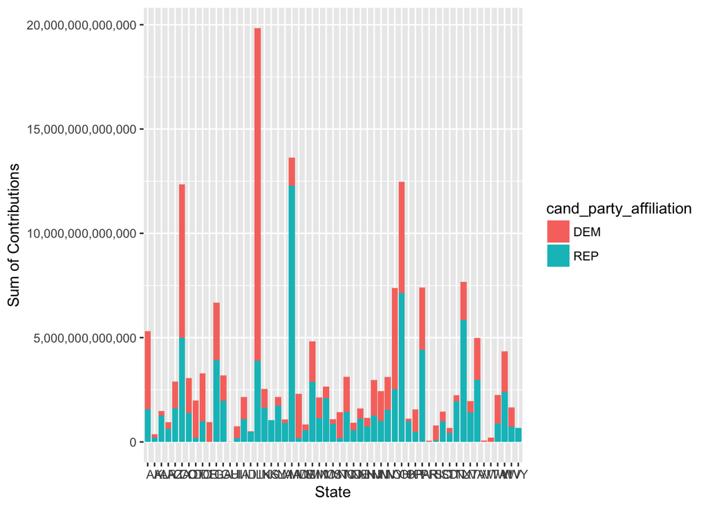

```
## # A tibble: 5,628 × 15
##      cand_id                 cand_name cand_party_affiliation
##        <chr>                     <chr>                  <chr>
## 1  H0AK00089      CRAWFORD, HARRY T JR                    DEM
## 2  H0AK00097          COX, JOHN ROBERT                    REP
## 3  H0AL00016     BOZEMAN, MARTHA RENEE                    UNK
## 4  H0AL01030    GOUNARES, PETER HUNTER                    REP
## 5  H0AL02087              ROBY, MARTHA                    REP
## 6  H0AL05049 CRAMER, ROBERT E "BUD" JR                    DEM
## 7  H0AL05155         PHILLIP, LESTER S                    REP
## 8  H0AL05163                BROOKS, MO                    REP
## 9  H0AL05189         SHEPARD, TAZEWELL                    DEM
## 10 H0AL05197      RABY, STEPHEN WALKER                    DEM
## # ... with 5,618 more rows, and 12 more variables: cand_election_yr <int>,
## #   cand_office_state <chr>, cand_office <chr>,
## #   cand_office_district <int>, cand_ici <chr>, cand_status <chr>,
## #   cand_pcc <chr>, cand_st1 <chr>, cand_st2 <chr>, cand_city <chr>,
## #   cand_state <chr>, cand_zip <int>
```

### Joining the Data

**Sarah:** Making a Big Data Collection house_elections, candidates Candidate elections include the names, states, incumbency status, party, number of votes (general), winner status and office

```r
##renaming columns in candidates in order to combine candidates and house_elections
candidates <- candidates %>%
  rename(state = cand_state,
         candidate_name = cand_name,
         year = cand_election_yr)

##mutating the chr of house_elections to merge candidates and house_elections by candidate names
house_elections <- house_elections %>%
  mutate_each(funs(toupper))

##converting chr value house_elections$general_votes to int values
house_elections$general_votes <- as.numeric(house_elections$general_votes)

##inner_join candidate elections
cand_elections <- candidates %>%
  inner_join(house_elections, by  = c("candidate_name" = "candidate_name", "state"="state"))


##cutting cand_elections down to include only necessary columns
cand_elections <- cand_elections %>%
  select(candidate_name, year, state, incumbent, party, general_votes, ge_winner, cand_office)
```

## Let’s look at Arizona House Elections

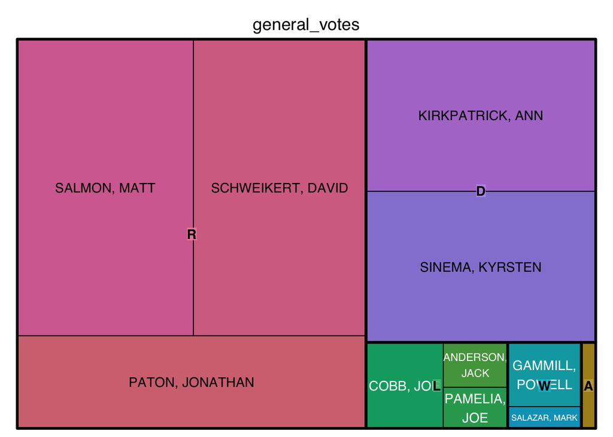

```r
##Arizona treemap
ariz_cand_elec <- cand_elections %>%
  filter(state == "AZ", cand_office == "H") %>%
  mutate(prop_votes = general_votes/sum(general_votes))

treemap(ariz_cand_elec, index = c("party", "candidate_name"), vSize = "general_votes", vColor = c("party", "incumbent"))
```

## Function by State

This function generates a tree graph with proportions showing the breakdown of votes by party and by candidates per state in the 2012 House election cycle. From this graphic you can see (for each state) how the votes were broken down.

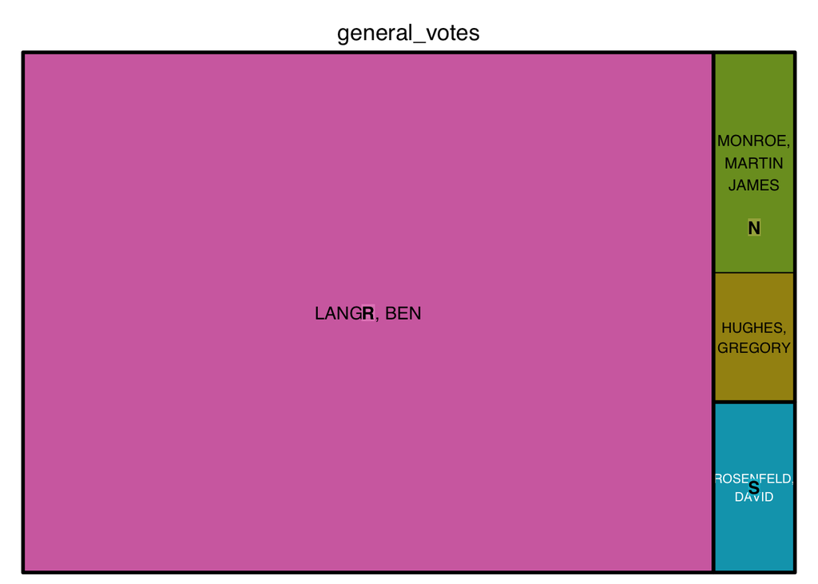

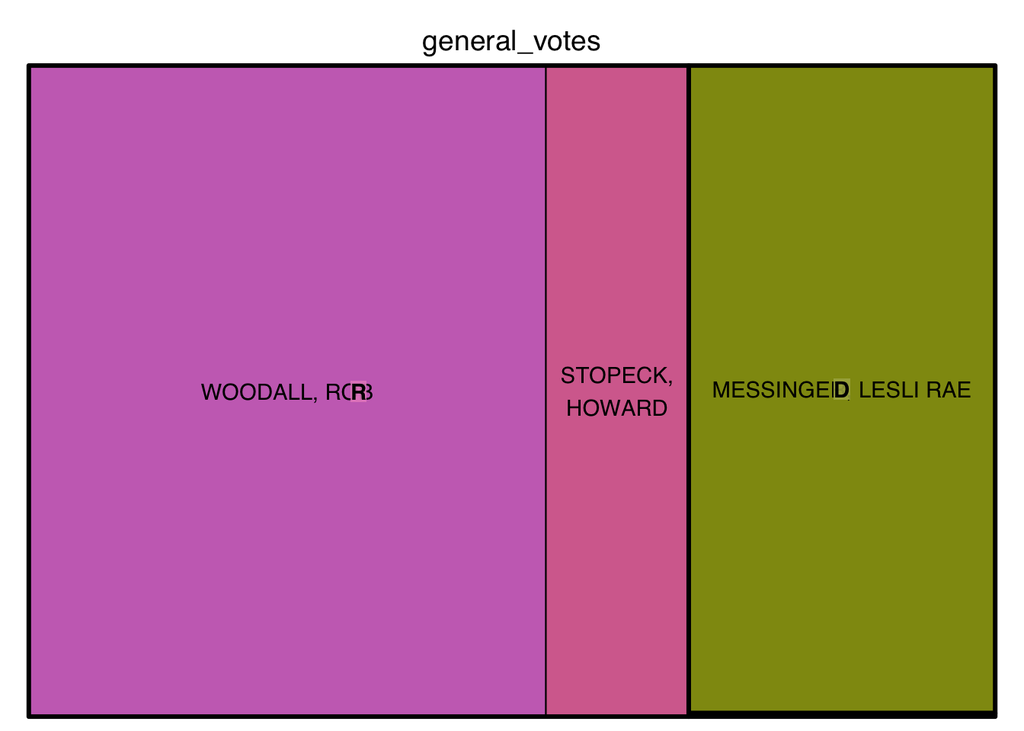

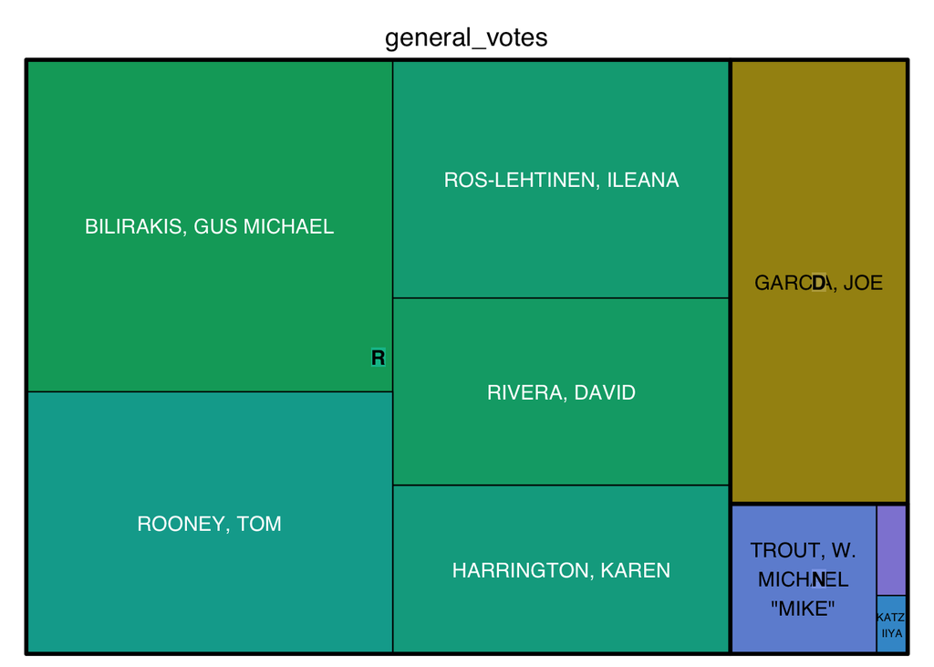

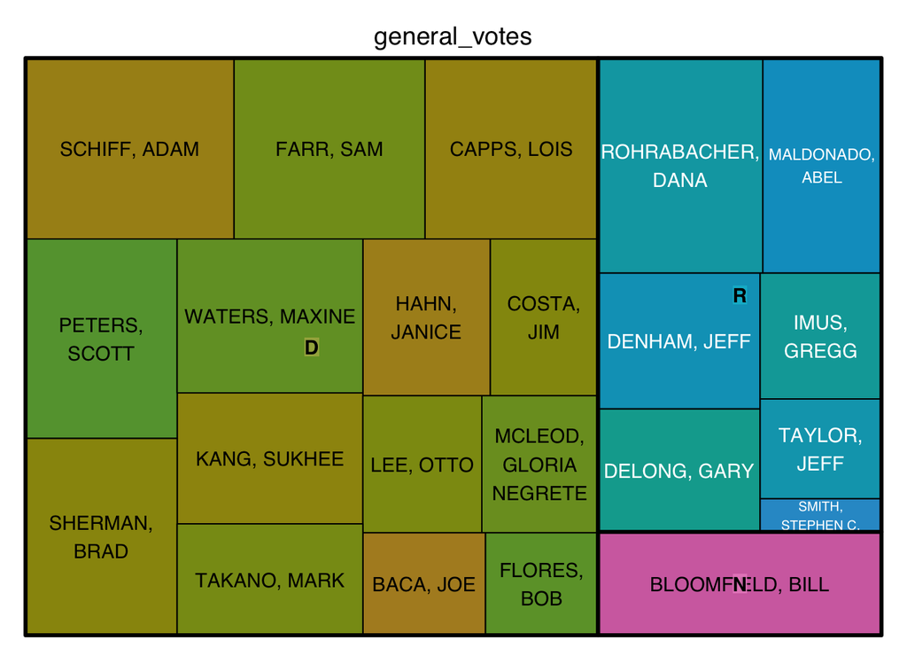

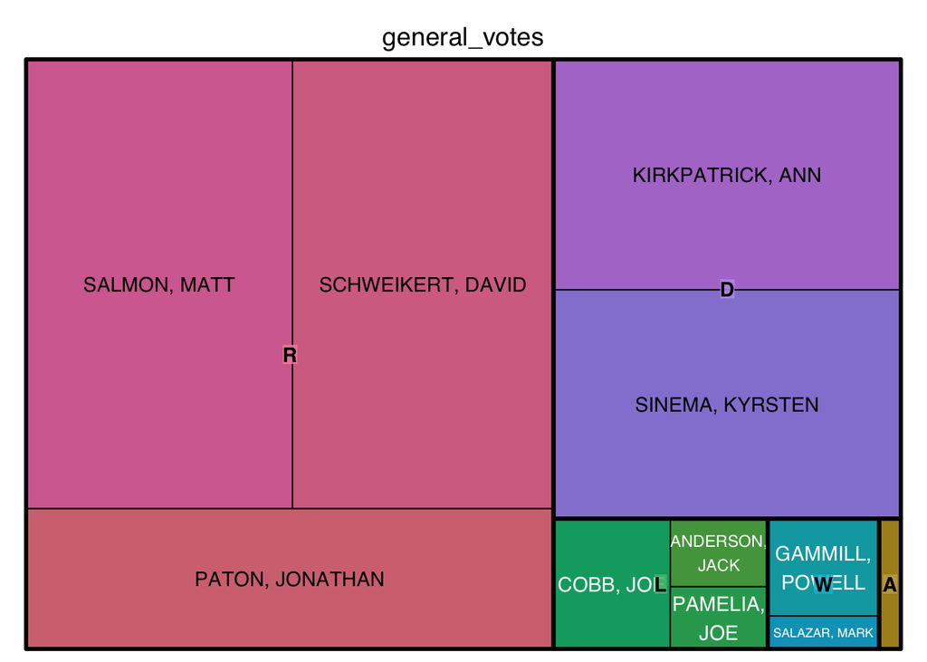

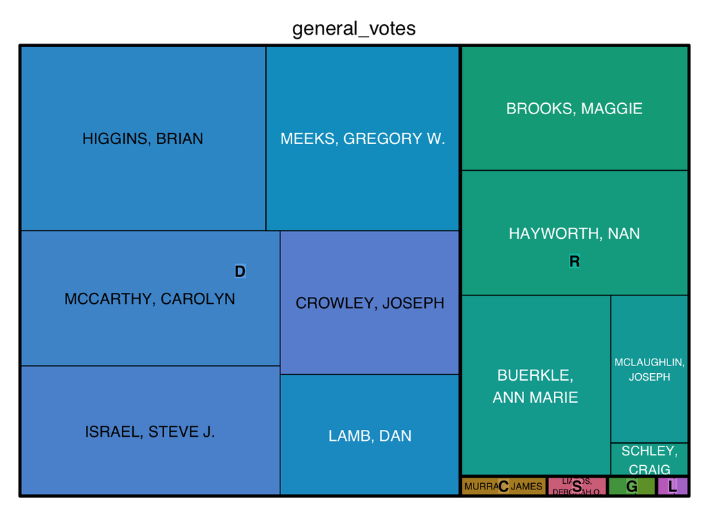

```r
##function that generates a tree graph with a breakdown of candidates and party and number ofvotes in the general election
percentage_breakdown <- function(this_state) {
  g4 <- cand_elections %>% filter(state == this_state, cand_office == "H", year == "2012")
  treemap(g4, index =  c("party", "candidate_name"), vSize = "general_votes", vColor = c("party", "incumbent"))
}
```

## Examining the House Elections

This graphic shows the distribution of votes by party in house elections, broken down by state. From these data it is possibly to see party dominance by state in house elections and see also the total number of votes.

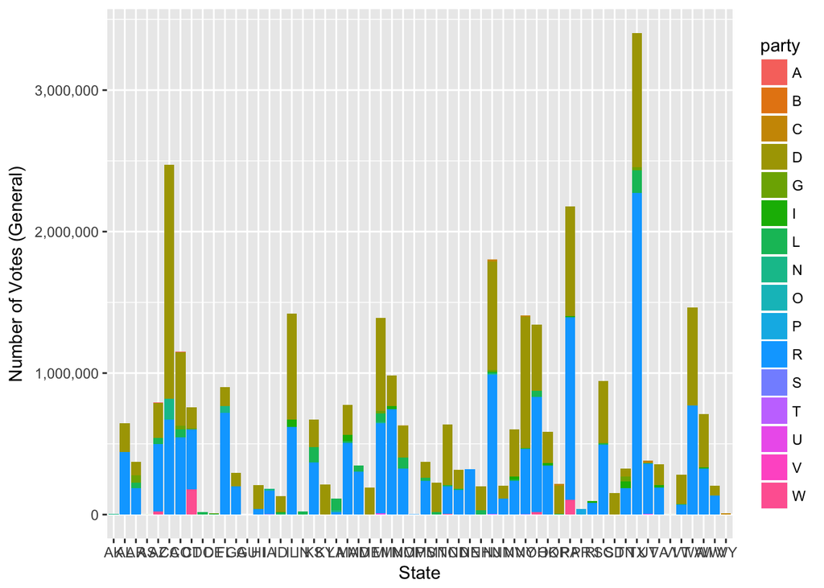

### Joining the Data

**Abby**: I chose to combine three of the datesets, excluding `committees` which contributed the least additional information. I used an `inner_join()` on `candidate_ID` - a variable unique to each candidate.

In the end, my joined dataset includes `candidate` and `contribution` data for each of 1,074 `house_election` candidates within the 2012 election cycle.

```r
# inner join on `candidate id`
big_join <- house_elections %>%
  inner_join(candidates, by = c("fec_id" ="cand_id")) %>%
  inner_join(contributions, by = c("fec_id" = "cand_id"))

# select only the variables of interest
all_data <- big_join %>%
  extract(cand_name, c("last_name", "first_name"), "([^ ]+), (.*)") %>%
  select(4:12, 15, 18, 24, 31:32, 35, 39:40) %>%
  mutate(transaction_dt = year(mdy(transaction_dt)))
```

## Attack Ads

**Attack ads** are designed to wage an attack against opposing candidates and political parties in the hopes that voters will be swayed toward the attacking candidate.

I chose to investigate the candidates who spent a larger share of their political contributions opposing the election of other candidates than on advocating their own election.

```r
# df of candidates with the highest absolute amount
# and pct of money going to attack ads
diff_per <- all_data %>%
  filter(cand_state != "" & transaction_amt > 0) %>%  # only postive $ amounts
  group_by(candidate_name) %>%
  mutate(total_contr = sum(transaction_amt)) %>%  # calculate total contributions per candidate
  group_by(candidate_name, transaction_type, total_contr) %>%
  # find total $$ per type of contribution
  summarize(per_type = sum(transaction_amt)) %>%  # calculate contributions per type for each candidate
  # filter by opposing or promoting
  filter(transaction_type=="24A" | transaction_type == "24E") %>%  # only include $ for attack ads and personal ads
  # find the percent spent per type
  mutate(pct_per_type = per_type/total_contr) %>%  # calculate percent of $ for each type
  arrange(desc(total_contr), desc(pct_per_type)) %>%
  filter(total_contr >= 500000) %>%
  select(-pct_per_type) %>%
  extract(candidate_name, c("last_name", "first_name"), "([^ ]+), (.*)", remove=FALSE) %>%  # re order first/last names
  spread(transaction_type, per_type, fill=0) %>%
  mutate(pct_pro = `24E`/total_contr,
         pct_con = `24A`/total_contr,
         con_to_pro = pct_con/pct_pro) %>%
  arrange(desc(total_contr), desc(pct_con))
```

The following graphs feature house candidates who had more than $500,000 USD of total contributions in their name.

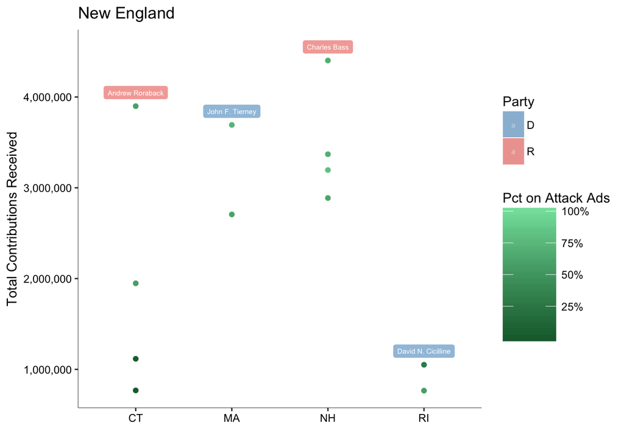

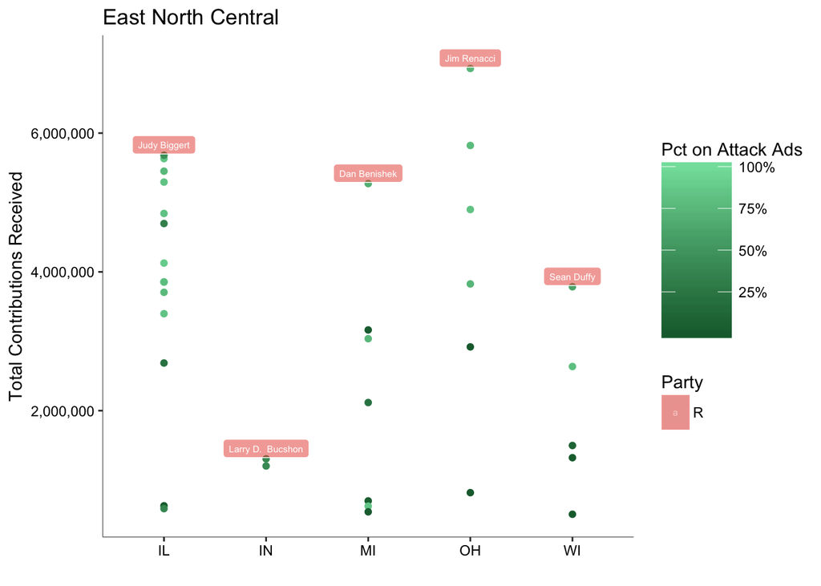

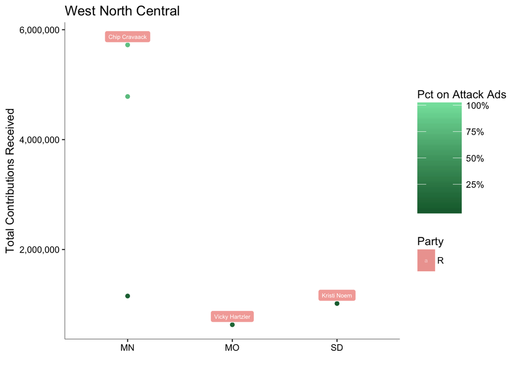

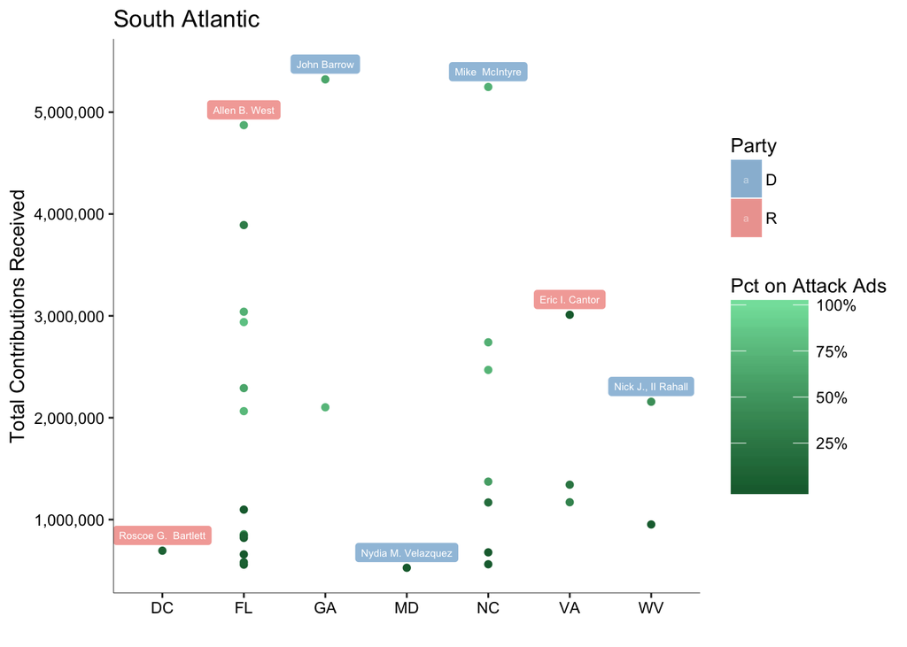

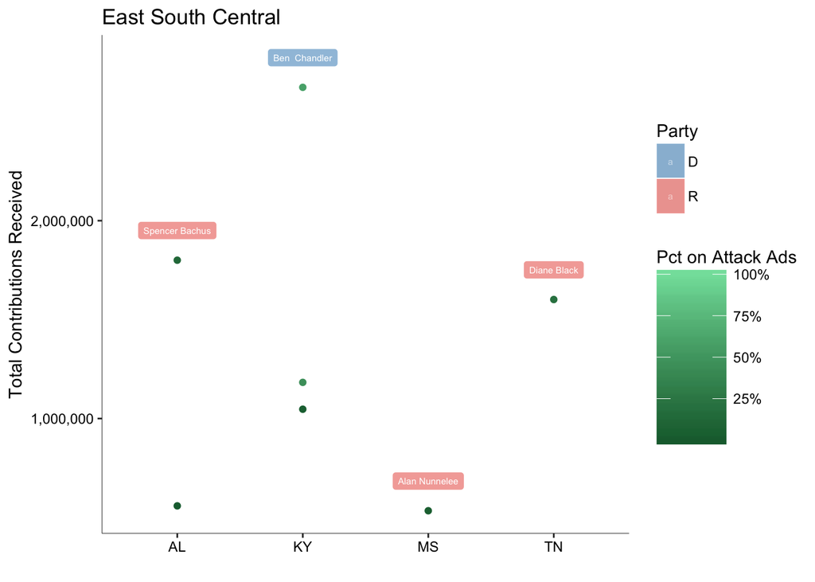

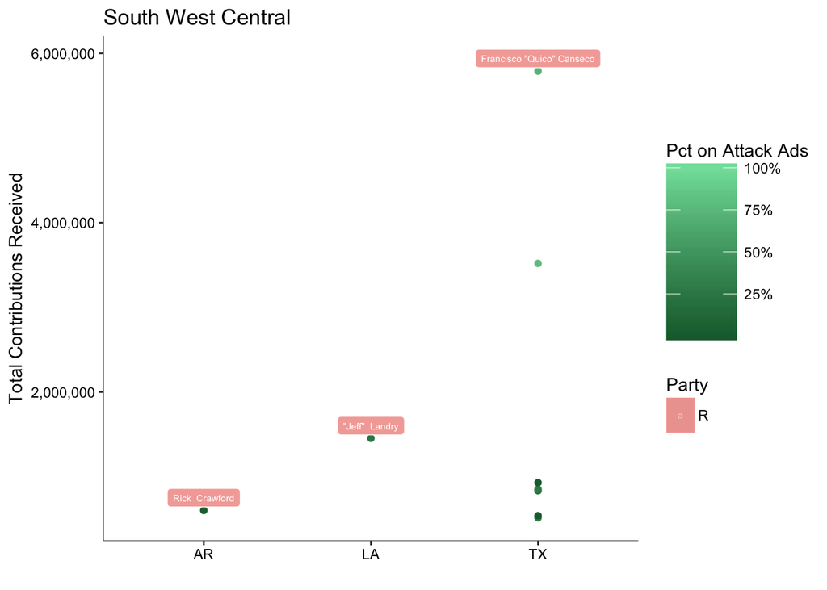

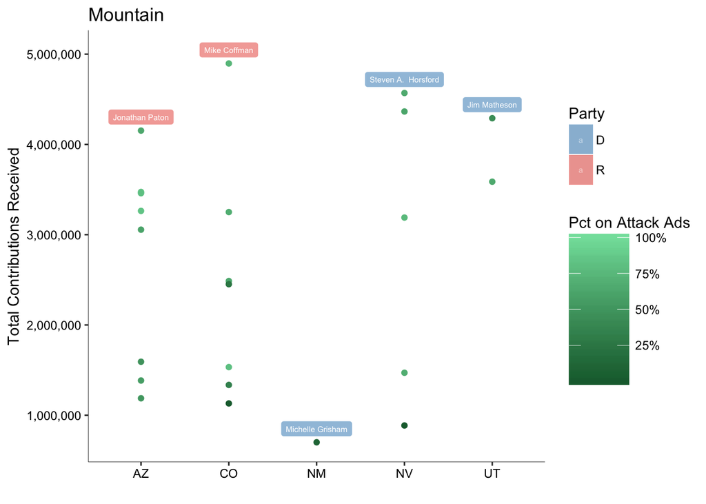

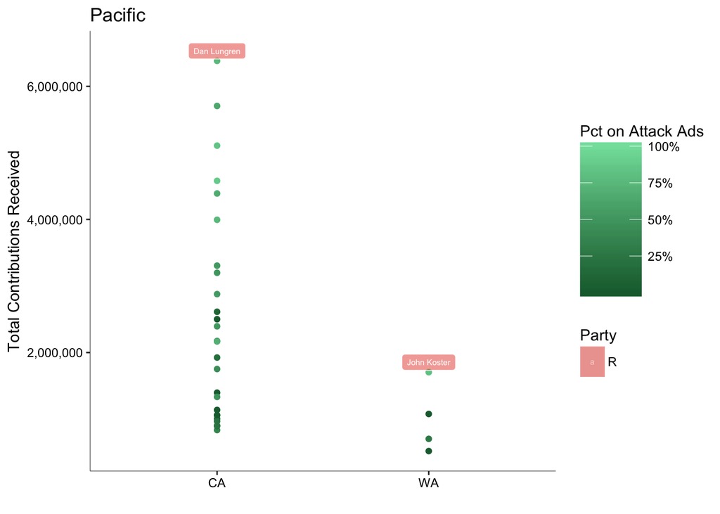

```r
regions <- c("New England", "East North Central", "West North Central", "South Atlantic", "East South Central", "South West Central", "Mountain", "Pacific")

party_cols <- c("R" = "#E74C3C", "D" = "#2980B9", "W" = "#F8C471")

pct_per_region_difference <- function(region_filter) {
  # for each region, filter the df to only include that region
  region_data <- cand_parties_difference %>%
    filter(region == region_filter)

  # create another df with candidates who had
  # the highest total contribution amount per state
  name_data <- region_data %>%
    arrange(cand_state, desc(total_contr))%>%
    group_by(cand_state) %>%
    slice(1)

  # plot each candidate and state, divided by US region
ggplot(region_data, aes(x=cand_state, y=total_contr, label = cand_name)) +
  geom_point(aes(color=pct_con)) +
  scale_color_gradient(low = "#186A3B", high = "#82E0AA",
                       guide=guide_colorbar(title="Pct on Attack Ads",
                                            barwidth = 3,
                                            title.hjust =0.5),
                       limits = c(0,1),
                       breaks=c(0.25, 0.50, 0.75, 1.0),
                       labels=c("25%", "50%","75%", "100%")) +
  geom_label(data=name_data, color="white", aes(fill=party), alpha=0.5, size=2, nudge_y = 150000) +
  scale_fill_manual(values=party_cols, guide=guide_legend(title="Party")) +
  xlab("") +
  ylab("Total Contributions Received") +
  theme(axis.text = element_text(color="black"),
        axis.line = element_line(color="black",
                                 size = 0.15),
        legend.key.height = unit(0.3, "in"),
        panel.background = element_rect(fill="white"),
        panel.grid = element_blank()) +
  ggtitle(region_filter)+
  scale_y_continuous(labels = scales::comma)
}
```

The graphs are broken down by geographical region, using US Census Bureau divisions.

Each point represents one candidate, placed vertically for their overall contributions received. The points are filled in with a shade of green depending on the percentage of their contributions that went to attack ads. The lighter the green, the larger the share of contributions that was spent on opposition campaigning.

I have also chosen to highlight the candidate in each state who had the largest overall contributions, with their name color-coded by political party. Here, the traditional red and blue are used to distinguish republicans and democrats, respectively.

Interestingly, more than 2/3 of the “highest spenders” (candidates who are labeled) were republicans.